# Replication of Figure A,B,C:Common Peaks Between TAZ, YAP, and TEAD4: Genomic Distribution and Signal Concordance

Harshini Muthukumar

2026-03-19

### Figure 1a

Figure 1a and 1b are venn-diagram showing the overlapping peak number of YAP/TAZ and YAP/TAZ/TEAD4

To find overlap/intersection of genomic regions, one can use the famous bedtools on command line or use GenomicRanges in R.

```r
TAZ_overlap_YAP_peaks<- subsetByOverlaps(TAZ_peaks, YAP_peaks)
length(TAZ_overlap_YAP_peaks)
```

```
## [1] 7154
```

```r
YAP_overlap_TAZ_peaks<- subsetByOverlaps(YAP_peaks, TAZ_peaks)
length(YAP_overlap_TAZ_peaks)
```

```
## [1] 7164
```

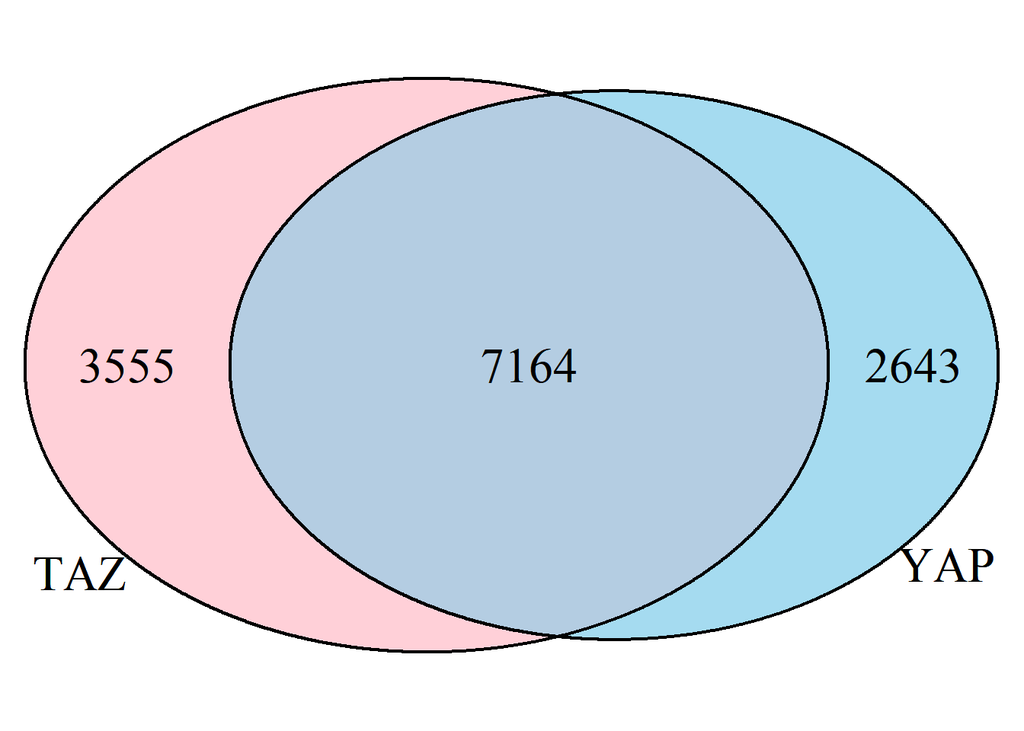

```r
n_YAP <- length(YAP_peaks)
n_TAZ <- length(TAZ_peaks)
n_overlap <- length(YAP_overlap_TAZ_peaks)

grid.newpage()

venn.plot <- draw.pairwise.venn(
  area1 = n_YAP,
  area2 = n_TAZ,
  cross.area = n_overlap,
  category = c("YAP", "TAZ"),
  fill = c("skyblue", "pink"),
  alpha = 0.5,
  cex = 2,
  cat.cex = 2
)

grid.draw(venn.plot)
```

## Figure 1: Overlap between TAZ and YAP ChIP-seq peaks

YAP (Yes-Associated Protein) and TAZ (Transcriptional Co-Activator with PDZ-binding motif) are the two core effectors of the Hippo signaling pathway. They are paralogs — meaning they share significant structural similarity and are often assumed to bind the same genomic regions.

However, whether they truly co-occupy the same sites across the genome, or have distinct.binding preferences, is a key biological question.To address this, we called peaks from ChIP-seq experiments for both YAP and TAZ separately and then asked: how much do their binding sites overlap? The Venn diagram shows that out of all peaks identified, **7,164 are shared** between YAP and TAZ, while **3,555 are TAZ-specific** and **2,643 are YAP-specific**.

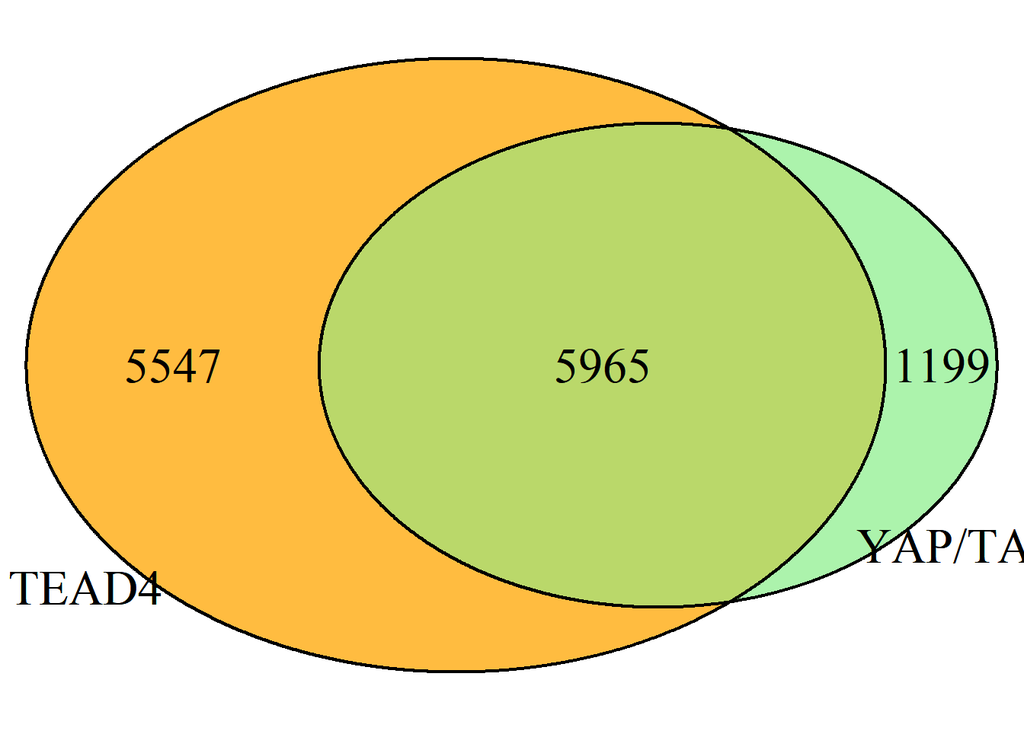

```r
TEAD4_peak<- import(here("C:/Users/harzi/OneDrive/Desktop/chip_seq_peak/TEAD4_peaks.narrowPeak"))

YAP_overlap_TAZ_peaks_overlap_TEAD4<- subsetByOverlaps(YAP_overlap_TAZ_peaks, TEAD4_peak)


n_YAP_TAZ <- length(YAP_overlap_TAZ_peaks)
n_TEAD4 <- length(TEAD4_peak)
n_overlap2 <- length(YAP_overlap_TAZ_peaks_overlap_TEAD4)

grid.newpage()

venn.plot2 <- draw.pairwise.venn(
  area1 = n_YAP_TAZ,
  area2 = n_TEAD4,
  cross.area = n_overlap2,
  category = c("YAP/TAZ", "TEAD4"),
  fill = c("lightgreen", "orange"),
  alpha = 0.5,
  cex = 2,
  cat.cex = 2
)

grid.draw(venn.plot2)
```

## Figure 2: Overlap between TEAD4 and YAP/TAZ binding sites

YAP and TAZ are **transcriptional co-activators** — they do not bind DNA directly. Instead,they work by physically interacting with DNA-binding transcription factors, most prominently the TEAD family (TEAD1–4). TEAD4 is the dominant TEAD family member in many cell types and serves as the primary DNA anchor that recruits YAP/TAZ to target gene promoters and enhancers.

To validate that the YAP/TAZ peaks we identified are functionally meaningful, we asked: do the combined YAP/TAZ binding sites (from Figure 1) overlap with regions bound by TEAD4? The Venn diagram shows that **5,965 sites are shared** between TEAD4 and YAP/TAZ, representing the canonical YAP/TAZ–TEAD co-bound regions that are most likely to be actively regulating transcription.

TEAD4 has **5,547 unique sites** — these may reflect TEAD4 binding with other co-factors independently of YAP/TAZ. Only **1,199 YAP/TAZ sites** lack TEAD4, which could represent TEAD-independent YAP/TAZ interactions (e.g., via AP-1 or other partners). This overlap analysis gives us confidence that our ChIP-seq peaks are capturing biologically relevant co-regulatory complexes.

### Fig 1C

```r
TEAD4_summit[queryHits(hits)][summit_distance ==0]
```

```
## GRanges object with 241 ranges and 2 metadata columns:
##         seqnames    ranges strand |             name     score
##            <Rle> <IRanges>  <Rle> |      <character> <numeric>
##     [1]     chr1   8137853      * |    TEAD4_peak_29   15.8382
##     [2]     chr1  17128622      * |    TEAD4_peak_91   30.2536
##     [3]     chr1  26351760      * |   TEAD4_peak_141   28.7604
##     [4]     chr1  27538961      * |   TEAD4_peak_154   35.3297
##     [5]     chr1  31576032      * |   TEAD4_peak_180   15.1534
##     ...      ...       ...    ... .              ...       ...
##   [237]     chr9 124659491      * | TEAD4_peak_11273   20.8842
##   [238]     chrX 101208246      * | TEAD4_peak_11442   10.7734
##   [239]     chrX 120120430      * | TEAD4_peak_11469   31.8595
##   [240]     chrX 120734965      * | TEAD4_peak_11472   22.8128
##   [241]     chrX 152896547      * | TEAD4_peak_11501   26.4184
##   -------
##   seqinfo: 24 sequences from an unspecified genome; no seqlengths
```

```r
TAZ_summit[subjectHits(hits)][summit_distance ==0]
```

```
## GRanges object with 241 ranges and 2 metadata columns:
##         seqnames    ranges strand |           name     score
##            <Rle> <IRanges>  <Rle> |    <character> <numeric>
##     [1]     chr1   8137853      * |    TAZ_peak_28   18.2561
##     [2]     chr1  17128622      * |    TAZ_peak_83   24.3522
##     [3]     chr1  26351761      * |   TAZ_peak_125   34.6508
##     [4]     chr1  27538962      * |   TAZ_peak_139   22.6101
##     [5]     chr1  31576031      * |   TAZ_peak_166   34.7791
##     ...      ...       ...    ... .            ...       ...
##   [237]     chr9 124659490      * | TAZ_peak_10496   8.61708
##   [238]     chrX 101208245      * | TAZ_peak_10652   6.40776
##   [239]     chrX 120120431      * | TAZ_peak_10678  20.78260
##   [240]     chrX 120734964      * | TAZ_peak_10683  10.32590
##   [241]     chrX 152896547      * | TAZ_peak_10711  13.43570
##   -------
##   seqinfo: 28 sequences from an unspecified genome; no seqlengths
```

```r
summit_distance<- signed_distance(TEAD4_summit[queryHits(hits)],
                                  TAZ_summit[subjectHits(hits)])

distance_df<- table(summit_distance) %>%
  tibble::as_tibble()

distance_df
```

```
## # A tibble: 383 × 2
##    summit_distance     n
##    <chr>           <int>
##  1 -249                1
##  2 -246                2
##  3 -233                1
##  4 -232                2
##  5 -231                1
##  6 -224                2
##  7 -222                1
##  8 -221                1
##  9 -220                1
## 10 -216                1
## # ℹ 373 more rows
```

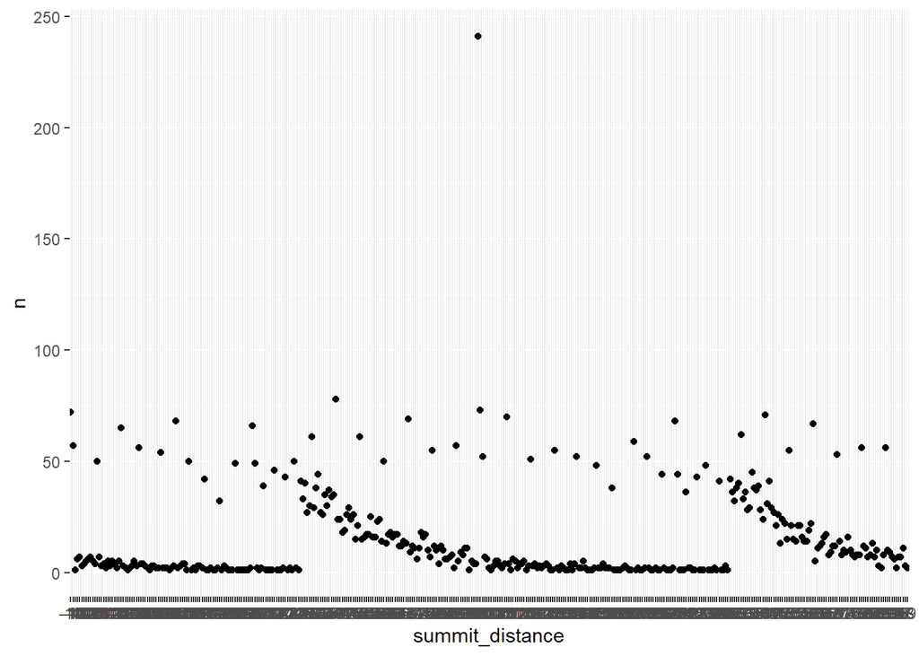

```r
distance_df %>%
  ggplot(aes(x=summit_distance, y = n)) +
  geom_point()
```

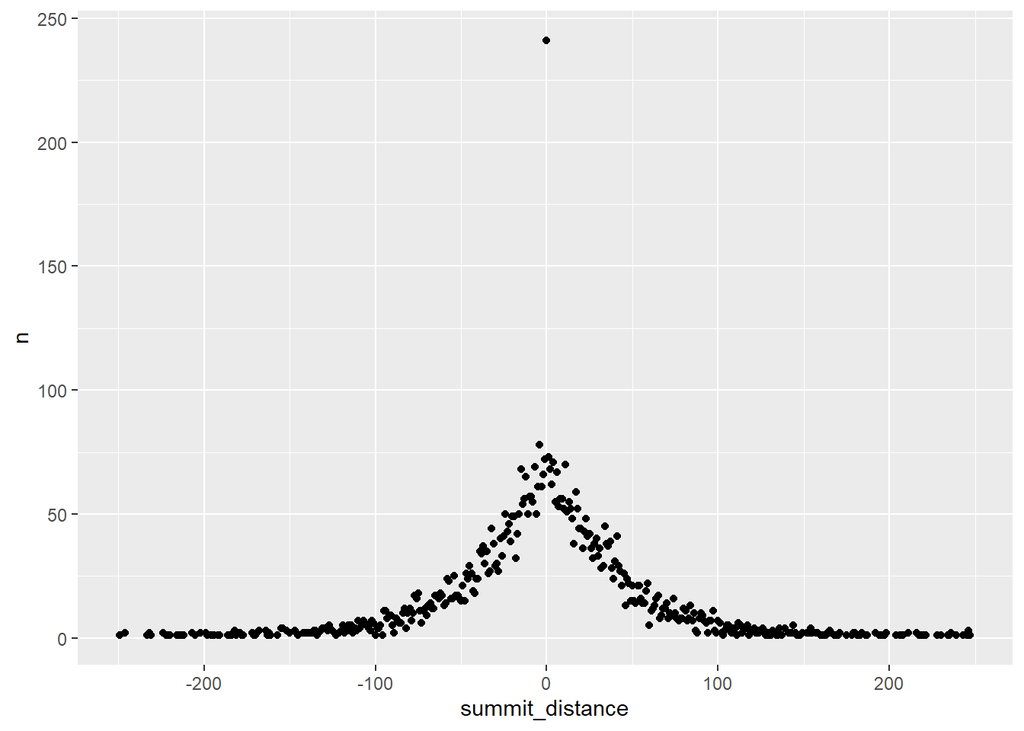

```r
distance_df %>%
  mutate(summit_distance = as.numeric(summit_distance)) %>%
  arrange(summit_distance) %>%
  ggplot(aes(x=summit_distance, y = n)) +
  geom_point()
```

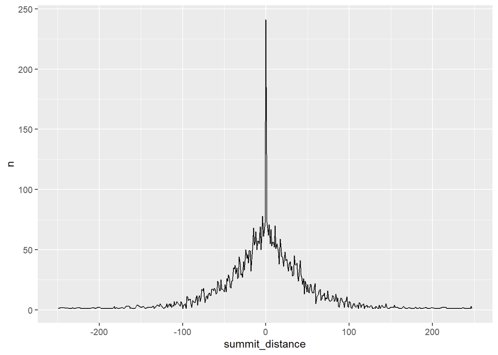

[figure not shown]

```r
distance_df %>%
  mutate(summit_distance = as.numeric(summit_distance)) %>%
  arrange(summit_distance) %>%
  ggplot(aes(x=summit_distance, y = n)) +
  geom_line()
```